# Frequency of Exceedences Analysis

# Introduction

The bacteria data is highly skewed. We have found no ready way to estimate a gemometric mean for these data in a robust way. The data appears distributed close to a Pareto distribution, which is highly skewed, with a heavy right tail. This distribution is likely to be difficult to model, so we can not readily estimate parameters, moments and other summary statistics.

One possiblity would be to run some sort of (generalized) linear model on the log of data, calculate means and medians, and back transform. I hope to explore both linear model approaches in another R Notebook.

| Growing Area Classification | Activity Allowed | Geometric mean FC/100ml | 90th Percentile (P90) FC/100ml |
| --- | --- | --- | --- |
| Approved | Harvesting allowed | ≤ 14 | ≤ 31 |
| Conditionally Approved | Harvesting allowed except during specified conditions | ≤ 14 in open status | ≤ 31 in open status |
| Restricted | Depuration harvesting or relay only | ≤ 88 and >15 | ≤ 163 and >31 |
| Conditionally Restricted | Depuration harvesting or relay allowed except during specified conditions | ≤ 88 in open status | ≤ 163 in open status |
| Prohibited | Aquaculture seed production only | >88 | >163 |

So, critical levels for Geometric Mean include: $<=14$ and $<= 88$ and for the p90 $< 31$ and $<= 163$

# Load Libraries

```r
library(MASS)
library(readr)
library(GGally)
library(tidyverse)
library(emmeans)
```

# Load Data

```r
sibfldnm <- 'Derived Data'
parent <- dirname(getwd())
sibling <- file.path(parent,sibfldnm)
fn = 'Shellfish data 2015 2018.csv'
path <- file.path(sibling, fn)
coli_data <- read_csv(path)
```

## Convert to Factors

```r
coli_data <- coli_data %>%
  mutate_at(4:8, factor) %>%
  mutate(Class = factor(Class,levels = c( 'A', 'CA', 'CR',
                                         'R', 'P', 'X' ))) %>%
  mutate(Tide = factor(Tide, levels = c("L", "LF", "F", "HF",
                                        "H", "HE", "E", "LE"))) %>%
  mutate(MONTH = factor(MONTH, labels = month.abb))
```

## Calculate Indicator Variables

Here we calculate variables that indicate whether each sample exceeds our four thresholds. Then they are combined to produce three additional synthetic multinomial ordered factors.

So, the key thresholds are these:

```r
coli_limits <- list(low = 0, gmlow=14, p90low=31, gmhigh=88, p90high=163, high= 5000)
freq_data<- coli_data %>%
  filter(! is.na(ColiVal)) %>%
  mutate(lvl4 = cut(ColiVal, coli_limits, labels = c('low', 'gmlow', 'p90low', 'gmhigh', 'p90high'))) %>%
  mutate(lvl1lo = cut(ColiVal, coli_limits[c(1,3,6)], labels = c('low', 'p90low'))) %>%
  mutate(lvl1hi = cut(ColiVal, coli_limits[c(1,5,6)], labels = c('low', 'p90high')))
freq_data <- freq_data %>%
  select(-ColiScore, -RawColi, -LCFlag, -RCFlag, -ColiVal)
```

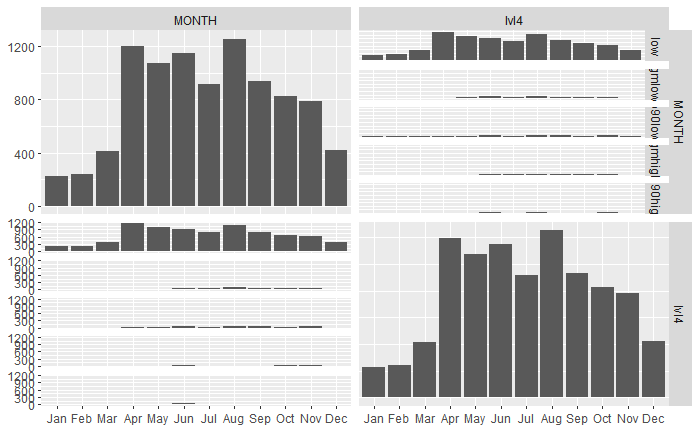

```r
freq_data %>% select(MONTH, lvl4) %>%
  mutate(MONTH=factor(MONTH)) %>%
  ggpairs(aes(MONTH, lvl4))
```

```r
NA
```

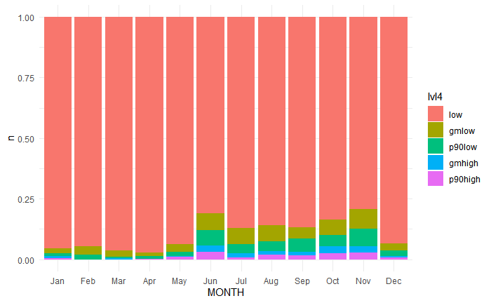

```r
mo_agg_dat <- freq_data %>%
  mutate(MONTH = factor(MONTH, labels =month.abb)) %>%
  count(MONTH, lvl4)

plt <- ggplot(mo_agg_dat, aes(MONTH, n, fill=lvl4)) +
   geom_bar(stat = "identity", position='fill') +
  theme_minimal()

plt
```

```r
NA
```

# Modelling

We’ll explore three different modelling strategies: 1. A binomial GLM for exceedences of the LOWER p90 threshold 2. A multinomial proportional odds model using the polr function from MASS 3. A mutinomial model using VGLM

It’s clear we need to account for different sampling histories to provide robust comperable estimates of site probabilities.

# Binomial GLM

## Preliminaries

I’ll want to be able to compare the results of modelling to observed relative frequencies of exceedences, so we want a simple dataframe containing those probabilities. If I were using these for serious analysis I’d derive them directly from the raw coli_data , rather than the derived freq_data.

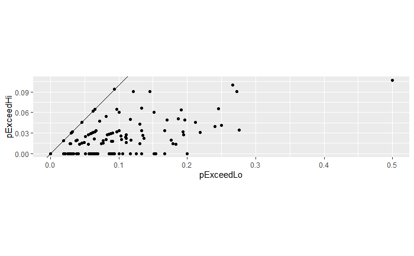

```r
rawexceedences <- freq_data %>%
  filter(! is.na(lvl1lo) & ! is.na(lvl1hi)) %>%
  group_by(Station) %>%
  summarize(pExceedLo = sum(lvl1lo == 'p90low', na.rm=TRUE)/sum(!is.na(lvl1lo)),
            pExceedHi = sum(lvl1hi == 'p90high', na.rm=TRUE)/sum(!is.na(lvl1hi)))
ggplot(rawexceedences, aes(pExceedLo, pExceedHi)) +
  geom_point() +
  geom_abline(intercept = 0, slope = 1) +
  coord_equal()
```

Which looks pretty good.